# inference_a

## Exploratory Data Analysis

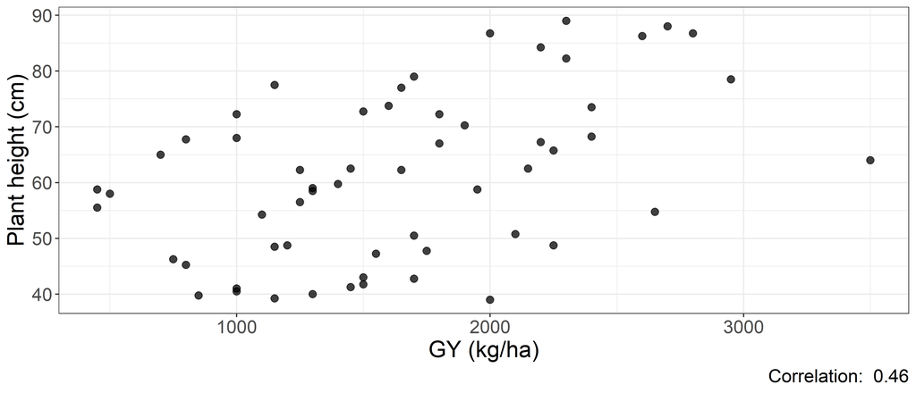

```r
ggplot(data = dat_sub, aes(x = GY, y = PH_R8)) +
  geom_point(size = 2.5, alpha = .75, color = "black")+
  theme_bw() +
  theme(text = element_text(size = 18)) +
  labs(x = "GY (kg/ha)", y = "Plant height (cm)",
       caption = paste("Correlation: ",
                       round(cor(dat_sub$GY, dat_sub$PH_R8, use = "na.or.complete"), 2)))
```

## Exploratory Data Analysis

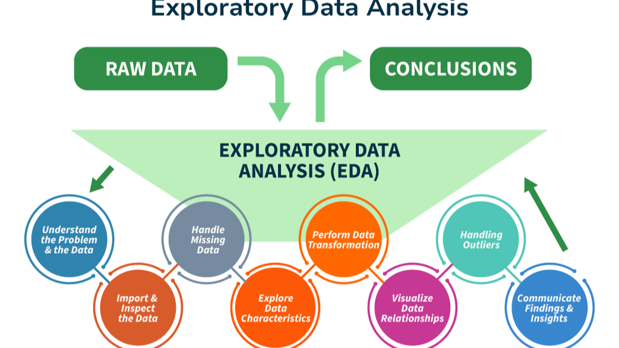

[Tariq A.](https://www.linkedin.com/pulse/comprehensive-guide-exploratory-data-analysis-eda-machine-tariq-ali-lnwmc)

## Exploratory Data Analysis

- Check the variation range of your dataset
- Check if your data follow the biological expectation
- Detect possible outliers, errors and inconsistencies throughout the trial
- Investigate the relationship between traits
- Guide your analysis toward a more informed model
- We will check other EDA tools throughout this course

## Your turn

Choose a random trial and perform exploratory data analysis with three traits: GY, PH and NDM. Then, compute the correlation between these traits and build pairwise scatter plots.

## Recommended websites

- [Real Life Examples of Various Distributions](https://www.somesolvedproblems.com/2019/04/real-life-examples-of-various.html)
- [**Exploratory Data Analysis with R**](https://bookdown.org/rdpeng/exdata/)
- [**Introduction to Statistics: A Data Science Perspective with R**](https://bookdown.org/dsciencelabs/intro_statistics/)
- [**R for data science**](https://r4ds.hadley.nz/)
  - [Solutions to exercises](https://mine-cetinkaya-rundel.github.io/r4ds-solutions/)
- [**Flourish: tools for visualization**](https://flourish.studio/)

## Recommended literature

Casella, G., & Berger, R. L. (2002). *Statistical Inference* (2nd ed.). Chapman; Hall/CRC. https://doi.org/10.1201/9781003456285

Gornick, L., & Smith, W. (1993). *The Cartoon Guide to Statistics* (1st ed.). HarperPerennial.